# Data Quality Check Report

Insitute for Alpine Environment, Eurac Research

Report start at **2017-12-21 11:54:04**

### INPUT info:

File selected: **M3.dat**

You have also select these parameters:

- Data start from row: *5*
- The name of column is on row: *2*
- The datetime header is: *TIMESTAMP*
- The record header is: *RECORD*
- The datetime format is: *yyyy-mm-dd HH:MM*
- The sampling interval is: *15 min*

The folders are:

- Input data folder: *H:/Projekte/Klimawandel/Experiment/data/2order/DQC_BrC_test_data/*
- Output data folder: *H:/Projekte/Klimawandel/Experiment/data/2order/DQC_BrC_test_data/test_output/Out_Data/*
- Output report folder: *H:/Projekte/Klimawandel/Experiment/data/2order/DQC_BrC_test_data/test_output/Out_Report/*
- Project folder: *H:/Projekte/Klimawandel/Experiment/data/2order/DataQualityCheckEuracAlpEnv/*

Range file in *H:/Projekte/Klimawandel/Experiment/data/2order/DataQualityCheckEuracAlpEnv/Data/Support_files/Range/* is called: *Range.csv*

You decide: *to don’t write output file*

And: *to don’t write output report*

### OUTPUT:

#### **Is the file empty?** NO: all right!

Ok: M3.dat is not empty

#### **There are problems in data file structure?** NO: all right!

There isn’t any problems

#### **The file is already process?** NO: all right!

#### **There are duplicated rows?** NO: all right!

There isn’t any duplicated row

#### **There are overlaps?** NO: all right!

There isn’t any overlap!

#### **There are missing dates?** NO: all right!

There isn’t any missing dates!

#### **Do you need to update the range file?** No, the range file is up to date!

Any new variable in range file: Range.csv

#### **Which values are out of physical range?**

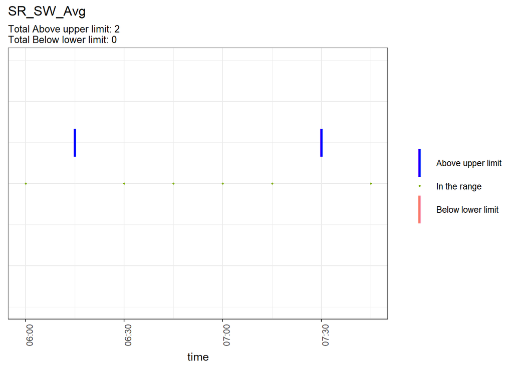

|  | From | To | Number of Record | Hours |
| --- | --- | --- | --- | --- |
| Above upper limit | 2017-11-23 06:15:00 | 2017-11-23 06:15:00 | 1 | 0.25 hours |
| Above upper limit | 2017-11-23 07:30:00 | 2017-11-23 07:30:00 | 1 | 0.25 hours |

*End Report - **2017-12-21 11:54:14***